# Risk Factor Analysis

## Outcome Variable

**Outcome Variable:** swasted

## Predictor Variables

**Intervention Variable:** birthwt

**Adjustment Set:**

unadjusted

## Stratifying Variables

The analysis was stratified on these variable(s):

- agecat
- studyid
- country

## Data Summary

| agecat | studyid | country | birthwt | swasted | n_cell | n | outcome_variable |
| --- | --- | --- | --- | --- | --- | --- | --- |
| Birth | ki0047075b-MAL-ED | BANGLADESH | Normal or high birthweight | 0 | 172 | 215 | swasted |
| Birth | ki0047075b-MAL-ED | BANGLADESH | Normal or high birthweight | 1 | 5 | 215 | swasted |
| Birth | ki0047075b-MAL-ED | BANGLADESH | Low birthweight | 0 | 35 | 215 | swasted |
| Birth | ki0047075b-MAL-ED | BANGLADESH | Low birthweight | 1 | 3 | 215 | swasted |
| Birth | ki0047075b-MAL-ED | BRAZIL | Normal or high birthweight | 0 | 60 | 62 | swasted |
| Birth | ki0047075b-MAL-ED | BRAZIL | Normal or high birthweight | 1 | 0 | 62 | swasted |
| Birth | ki0047075b-MAL-ED | BRAZIL | Low birthweight | 0 | 2 | 62 | swasted |
| Birth | ki0047075b-MAL-ED | BRAZIL | Low birthweight | 1 | 0 | 62 | swasted |
| Birth | ki0047075b-MAL-ED | INDIA | Normal or high birthweight | 0 | 38 | 45 | swasted |
| Birth | ki0047075b-MAL-ED | INDIA | Normal or high birthweight | 1 | 0 | 45 | swasted |
| Birth | ki0047075b-MAL-ED | INDIA | Low birthweight | 0 | 7 | 45 | swasted |
| Birth | ki0047075b-MAL-ED | INDIA | Low birthweight | 1 | 0 | 45 | swasted |
| Birth | ki0047075b-MAL-ED | NEPAL | Normal or high birthweight | 0 | 24 | 26 | swasted |
| Birth | ki0047075b-MAL-ED | NEPAL | Normal or high birthweight | 1 | 0 | 26 | swasted |
| Birth | ki0047075b-MAL-ED | NEPAL | Low birthweight | 0 | 1 | 26 | swasted |
| Birth | ki0047075b-MAL-ED | NEPAL | Low birthweight | 1 | 1 | 26 | swasted |
| Birth | ki0047075b-MAL-ED | PERU | Normal or high birthweight | 0 | 218 | 228 | swasted |
| Birth | ki0047075b-MAL-ED | PERU | Normal or high birthweight | 1 | 0 | 228 | swasted |
| Birth | ki0047075b-MAL-ED | PERU | Low birthweight | 0 | 10 | 228 | swasted |
| Birth | ki0047075b-MAL-ED | PERU | Low birthweight | 1 | 0 | 228 | swasted |
| Birth | ki0047075b-MAL-ED | SOUTH AFRICA | Normal or high birthweight | 0 | 115 | 120 | swasted |
| Birth | ki0047075b-MAL-ED | SOUTH AFRICA | Normal or high birthweight | 1 | 0 | 120 | swasted |
| Birth | ki0047075b-MAL-ED | SOUTH AFRICA | Low birthweight | 0 | 5 | 120 | swasted |
| Birth | ki0047075b-MAL-ED | SOUTH AFRICA | Low birthweight | 1 | 0 | 120 | swasted |
| Birth | ki0047075b-MAL-ED | TANZANIA, UNITED REPUBLIC OF | Normal or high birthweight | 0 | 113 | 115 | swasted |
| Birth | ki0047075b-MAL-ED | TANZANIA, UNITED REPUBLIC OF | Normal or high birthweight | 1 | 0 | 115 | swasted |
| Birth | ki0047075b-MAL-ED | TANZANIA, UNITED REPUBLIC OF | Low birthweight | 0 | 2 | 115 | swasted |
| Birth | ki0047075b-MAL-ED | TANZANIA, UNITED REPUBLIC OF | Low birthweight | 1 | 0 | 115 | swasted |
| Birth | ki1000108-CMC-V-BCS-2002 | INDIA | Normal or high birthweight | 0 | 76 | 86 | swasted |
| Birth | ki1000108-CMC-V-BCS-2002 | INDIA | Normal or high birthweight | 1 | 0 | 86 | swasted |

[output cut: 282 more lines]

The following strata were considered:

- agecat: 24 months, studyid: ki0047075b-MAL-ED, country: BANGLADESH
- agecat: 24 months, studyid: ki0047075b-MAL-ED, country: BRAZIL
- agecat: 24 months, studyid: ki0047075b-MAL-ED, country: INDIA
- agecat: 24 months, studyid: ki0047075b-MAL-ED, country: NEPAL
- agecat: 24 months, studyid: ki0047075b-MAL-ED, country: PERU
- agecat: 24 months, studyid: ki0047075b-MAL-ED, country: SOUTH AFRICA
- agecat: 24 months, studyid: ki0047075b-MAL-ED, country: TANZANIA, UNITED REPUBLIC OF
- agecat: 24 months, studyid: ki1000108-CMC-V-BCS-2002, country: INDIA
- agecat: 24 months, studyid: ki1000108-IRC, country: INDIA
- agecat: 24 months, studyid: ki1000109-EE, country: PAKISTAN
- agecat: 24 months, studyid: ki1017093-NIH-Birth, country: BANGLADESH
- agecat: 24 months, studyid: ki1017093b-PROVIDE, country: BANGLADESH
- agecat: 24 months, studyid: ki1017093c-NIH-Crypto, country: BANGLADESH
- agecat: 24 months, studyid: ki1066203-TanzaniaChild2, country: TANZANIA, UNITED REPUBLIC OF
- agecat: 24 months, studyid: ki1101329-Keneba, country: GAMBIA
- agecat: 24 months, studyid: ki1113344-GMS-Nepal, country: NEPAL
- agecat: 24 months, studyid: ki1114097-CMIN, country: BANGLADESH
- agecat: 24 months, studyid: ki1114097-CONTENT, country: PERU
- agecat: 24 months, studyid: ki1119695-PROBIT, country: BELARUS
- agecat: 24 months, studyid: ki1126311-ZVITAMBO, country: ZIMBABWE
- agecat: 24 months, studyid: ki1135781-COHORTS, country: GUATEMALA
- agecat: 24 months, studyid: ki1135781-COHORTS, country: INDIA
- agecat: 24 months, studyid: ki1135781-COHORTS, country: PHILIPPINES
- agecat: 24 months, studyid: kiGH5241-JiVitA-3, country: BANGLADESH
- agecat: 24 months, studyid: kiGH5241-JiVitA-4, country: BANGLADESH
- agecat: 6 months, studyid: ki0047075b-MAL-ED, country: BANGLADESH
- agecat: 6 months, studyid: ki0047075b-MAL-ED, country: BRAZIL
- agecat: 6 months, studyid: ki0047075b-MAL-ED, country: INDIA
- agecat: 6 months, studyid: ki0047075b-MAL-ED, country: NEPAL
- agecat: 6 months, studyid: ki0047075b-MAL-ED, country: PERU
- agecat: 6 months, studyid: ki0047075b-MAL-ED, country: SOUTH AFRICA
- agecat: 6 months, studyid: ki0047075b-MAL-ED, country: TANZANIA, UNITED REPUBLIC OF
- agecat: 6 months, studyid: ki1000108-CMC-V-BCS-2002, country: INDIA
- agecat: 6 months, studyid: ki1000108-IRC, country: INDIA
- agecat: 6 months, studyid: ki1000109-EE, country: PAKISTAN
- agecat: 6 months, studyid: ki1000109-ResPak, country: PAKISTAN
- agecat: 6 months, studyid: ki1000304b-SAS-CompFeed, country: INDIA
- agecat: 6 months, studyid: ki1017093-NIH-Birth, country: BANGLADESH
- agecat: 6 months, studyid: ki1017093b-PROVIDE, country: BANGLADESH
- agecat: 6 months, studyid: ki1017093c-NIH-Crypto, country: BANGLADESH
- agecat: 6 months, studyid: ki1066203-TanzaniaChild2, country: TANZANIA, UNITED REPUBLIC OF
- agecat: 6 months, studyid: ki1101329-Keneba, country: GAMBIA
- agecat: 6 months, studyid: ki1113344-GMS-Nepal, country: NEPAL
- agecat: 6 months, studyid: ki1114097-CMIN, country: BANGLADESH
- agecat: 6 months, studyid: ki1114097-CONTENT, country: PERU
- agecat: 6 months, studyid: ki1119695-PROBIT, country: BELARUS
- agecat: 6 months, studyid: ki1126311-ZVITAMBO, country: ZIMBABWE
- agecat: 6 months, studyid: ki1135781-COHORTS, country: GUATEMALA
- agecat: 6 months, studyid: ki1135781-COHORTS, country: INDIA
- agecat: 6 months, studyid: ki1135781-COHORTS, country: PHILIPPINES
- agecat: 6 months, studyid: kiGH5241-JiVitA-3, country: BANGLADESH
- agecat: 6 months, studyid: kiGH5241-JiVitA-4, country: BANGLADESH
- agecat: Birth, studyid: ki0047075b-MAL-ED, country: BANGLADESH
- agecat: Birth, studyid: ki0047075b-MAL-ED, country: BRAZIL
- agecat: Birth, studyid: ki0047075b-MAL-ED, country: INDIA
- agecat: Birth, studyid: ki0047075b-MAL-ED, country: NEPAL
- agecat: Birth, studyid: ki0047075b-MAL-ED, country: PERU
- agecat: Birth, studyid: ki0047075b-MAL-ED, country: SOUTH AFRICA
- agecat: Birth, studyid: ki0047075b-MAL-ED, country: TANZANIA, UNITED REPUBLIC OF
- agecat: Birth, studyid: ki1000108-CMC-V-BCS-2002, country: INDIA
- agecat: Birth, studyid: ki1000108-IRC, country: INDIA
- agecat: Birth, studyid: ki1000109-EE, country: PAKISTAN
- agecat: Birth, studyid: ki1000109-ResPak, country: PAKISTAN
- agecat: Birth, studyid: ki1000304b-SAS-CompFeed, country: INDIA
- agecat: Birth, studyid: ki1017093-NIH-Birth, country: BANGLADESH
- agecat: Birth, studyid: ki1017093b-PROVIDE, country: BANGLADESH
- agecat: Birth, studyid: ki1017093c-NIH-Crypto, country: BANGLADESH
- agecat: Birth, studyid: ki1101329-Keneba, country: GAMBIA
- agecat: Birth, studyid: ki1113344-GMS-Nepal, country: NEPAL
- agecat: Birth, studyid: ki1114097-CMIN, country: BANGLADESH
- agecat: Birth, studyid: ki1114097-CONTENT, country: PERU
- agecat: Birth, studyid: ki1119695-PROBIT, country: BELARUS
- agecat: Birth, studyid: ki1126311-ZVITAMBO, country: ZIMBABWE
- agecat: Birth, studyid: ki1135781-COHORTS, country: GUATEMALA
- agecat: Birth, studyid: ki1135781-COHORTS, country: INDIA
- agecat: Birth, studyid: ki1135781-COHORTS, country: PHILIPPINES
- agecat: Birth, studyid: kiGH5241-JiVitA-3, country: BANGLADESH
- agecat: Birth, studyid: kiGH5241-JiVitA-4, country: BANGLADESH

### Dropped Strata

Some strata were dropped due to rare outcomes:

- agecat: Birth, studyid: ki0047075b-MAL-ED, country: BANGLADESH
- agecat: Birth, studyid: ki0047075b-MAL-ED, country: BRAZIL
- agecat: Birth, studyid: ki0047075b-MAL-ED, country: INDIA
- agecat: Birth, studyid: ki0047075b-MAL-ED, country: NEPAL
- agecat: Birth, studyid: ki0047075b-MAL-ED, country: PERU
- agecat: Birth, studyid: ki0047075b-MAL-ED, country: SOUTH AFRICA
- agecat: Birth, studyid: ki0047075b-MAL-ED, country: TANZANIA, UNITED REPUBLIC OF
- agecat: Birth, studyid: ki1000108-CMC-V-BCS-2002, country: INDIA
- agecat: Birth, studyid: ki1000109-EE, country: PAKISTAN
- agecat: Birth, studyid: ki1000109-ResPak, country: PAKISTAN
- agecat: Birth, studyid: ki1000304b-SAS-CompFeed, country: INDIA
- agecat: Birth, studyid: ki1017093b-PROVIDE, country: BANGLADESH
- agecat: Birth, studyid: ki1114097-CMIN, country: BANGLADESH
- agecat: Birth, studyid: ki1114097-CONTENT, country: PERU
- agecat: Birth, studyid: ki1119695-PROBIT, country: BELARUS
- agecat: Birth, studyid: kiGH5241-JiVitA-4, country: BANGLADESH
- agecat: 6 months, studyid: ki0047075b-MAL-ED, country: BANGLADESH
- agecat: 6 months, studyid: ki0047075b-MAL-ED, country: BRAZIL
- agecat: 6 months, studyid: ki0047075b-MAL-ED, country: INDIA
- agecat: 6 months, studyid: ki0047075b-MAL-ED, country: NEPAL
- agecat: 6 months, studyid: ki0047075b-MAL-ED, country: PERU
- agecat: 6 months, studyid: ki0047075b-MAL-ED, country: SOUTH AFRICA
- agecat: 6 months, studyid: ki0047075b-MAL-ED, country: TANZANIA, UNITED REPUBLIC OF
- agecat: 6 months, studyid: ki1000108-CMC-V-BCS-2002, country: INDIA
- agecat: 6 months, studyid: ki1000109-ResPak, country: PAKISTAN
- agecat: 6 months, studyid: ki1017093-NIH-Birth, country: BANGLADESH
- agecat: 6 months, studyid: ki1017093b-PROVIDE, country: BANGLADESH
- agecat: 6 months, studyid: ki1017093c-NIH-Crypto, country: BANGLADESH
- agecat: 6 months, studyid: ki1066203-TanzaniaChild2, country: TANZANIA, UNITED REPUBLIC OF
- agecat: 6 months, studyid: ki1113344-GMS-Nepal, country: NEPAL
- agecat: 6 months, studyid: ki1114097-CMIN, country: BANGLADESH
- agecat: 6 months, studyid: ki1114097-CONTENT, country: PERU
- agecat: 6 months, studyid: ki1119695-PROBIT, country: BELARUS
- agecat: 6 months, studyid: ki1135781-COHORTS, country: GUATEMALA
- agecat: 24 months, studyid: ki0047075b-MAL-ED, country: BANGLADESH
- agecat: 24 months, studyid: ki0047075b-MAL-ED, country: BRAZIL
- agecat: 24 months, studyid: ki0047075b-MAL-ED, country: INDIA
- agecat: 24 months, studyid: ki0047075b-MAL-ED, country: NEPAL
- agecat: 24 months, studyid: ki0047075b-MAL-ED, country: PERU
- agecat: 24 months, studyid: ki0047075b-MAL-ED, country: SOUTH AFRICA
- agecat: 24 months, studyid: ki0047075b-MAL-ED, country: TANZANIA, UNITED REPUBLIC OF
- agecat: 24 months, studyid: ki1000108-CMC-V-BCS-2002, country: INDIA
- agecat: 24 months, studyid: ki1000108-IRC, country: INDIA
- agecat: 24 months, studyid: ki1000109-EE, country: PAKISTAN
- agecat: 24 months, studyid: ki1017093-NIH-Birth, country: BANGLADESH
- agecat: 24 months, studyid: ki1017093b-PROVIDE, country: BANGLADESH
- agecat: 24 months, studyid: ki1017093c-NIH-Crypto, country: BANGLADESH
- agecat: 24 months, studyid: ki1066203-TanzaniaChild2, country: TANZANIA, UNITED REPUBLIC OF
- agecat: 24 months, studyid: ki1113344-GMS-Nepal, country: NEPAL
- agecat: 24 months, studyid: ki1114097-CMIN, country: BANGLADESH
- agecat: 24 months, studyid: ki1114097-CONTENT, country: PERU
- agecat: 24 months, studyid: ki1119695-PROBIT, country: BELARUS
- agecat: 24 months, studyid: ki1135781-COHORTS, country: GUATEMALA
- agecat: 24 months, studyid: ki1135781-COHORTS, country: PHILIPPINES

## Methods Detail

We’re interested in the causal parameters $E[Y_a]$ for all values of $a \in \mathcal{A}$. These parameters represent the mean outcome if, possibly contrary to fact, we intervened to set all units to have $A=a$. Under the randomization and positivity assumptions, these are identified by the statistical parameters $\psi_a=E_W[E_{Y|A,W}(Y|A=a,W)]$. In addition, we’re interested in the mean of $Y$, $E[Y]$ under no intervention (the observed mean). We will estimate these parameters by using SuperLearner to fit the relevant likelihood factors – $E_{Y|A,W}(Y|A=a,W)$ and $p(A=a|W)$, and then updating our likelihood fit using a joint TMLE.

For unadjusted analyses ($W=\{\}$), initial likelihoods were estimated using Lrnr_glm to estimate the simple $E(Y|A)$ and Lrnr_mean to estimate $p(A)$. For adjusted analyses, a small library containing Lrnr_glmnet, Lrnr_xgboost, and Lrnr_mean was used.

Having estimated these parameters, we will then use the delta method to estimate relative risks and attributable risks relative to a prespecified baseline level of $A$.

# Results Detail

## Results Plots

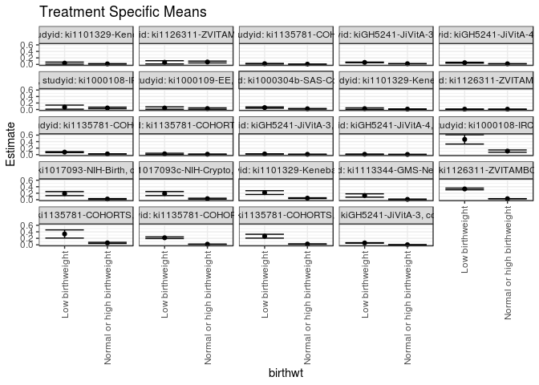

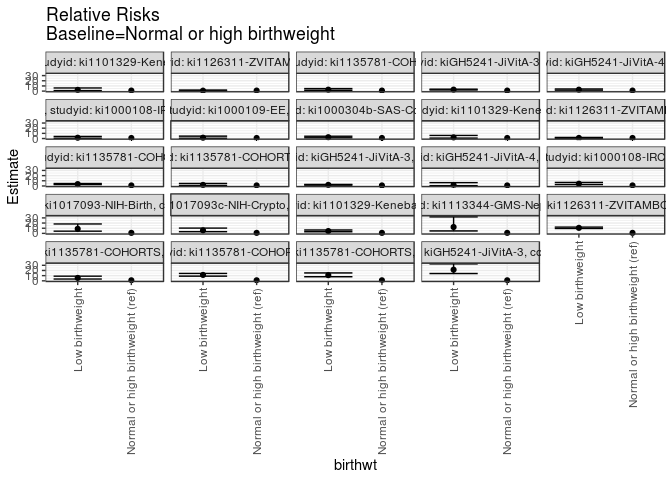

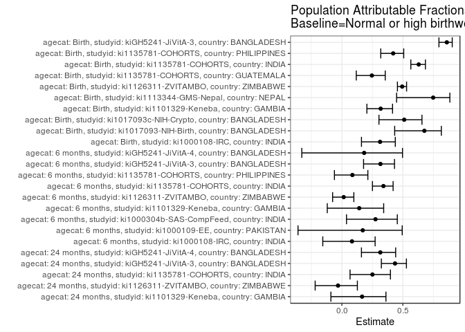

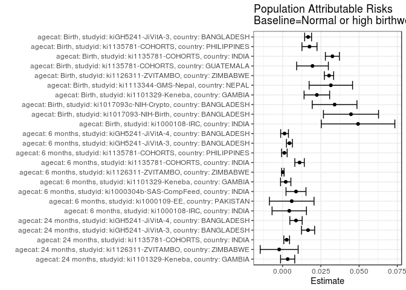

## Results Table

### Parameter: TSM

| agecat | studyid | country | intervention_level | baseline_level | estimate | ci_lower | ci_upper |
| --- | --- | --- | --- | --- | --- | --- | --- |
| Birth | ki1000108-IRC | INDIA | Normal or high birthweight | NA | 0.1081081 | 0.0726822 | 0.1435341 |
| Birth | ki1000108-IRC | INDIA | Low birthweight | NA | 0.4680851 | 0.3252231 | 0.6109471 |
| Birth | ki1017093-NIH-Birth | BANGLADESH | Normal or high birthweight | NA | 0.0213777 | 0.0075492 | 0.0352061 |
| Birth | ki1017093-NIH-Birth | BANGLADESH | Low birthweight | NA | 0.1883117 | 0.1265102 | 0.2501132 |
| Birth | ki1017093c-NIH-Crypto | BANGLADESH | Normal or high birthweight | NA | 0.0324910 | 0.0177166 | 0.0472654 |
| Birth | ki1017093c-NIH-Crypto | BANGLADESH | Low birthweight | NA | 0.1895425 | 0.1273943 | 0.2516906 |
| Birth | ki1101329-Keneba | GAMBIA | Normal or high birthweight | NA | 0.0479183 | 0.0361810 | 0.0596557 |
| Birth | ki1101329-Keneba | GAMBIA | Low birthweight | NA | 0.2187500 | 0.1602555 | 0.2772445 |
| Birth | ki1113344-GMS-Nepal | NEPAL | Normal or high birthweight | NA | 0.0105932 | 0.0013501 | 0.0198363 |
| Birth | ki1113344-GMS-Nepal | NEPAL | Low birthweight | NA | 0.1301775 | 0.0794052 | 0.1809498 |
| Birth | ki1126311-ZVITAMBO | ZIMBABWE | Normal or high birthweight | NA | 0.0309971 | 0.0278450 | 0.0341491 |
| Birth | ki1126311-ZVITAMBO | ZIMBABWE | Low birthweight | NA | 0.3315426 | 0.3059803 | 0.3571049 |
| Birth | ki1135781-COHORTS | GUATEMALA | Normal or high birthweight | NA | 0.0598291 | 0.0422730 | 0.0773851 |
| Birth | ki1135781-COHORTS | GUATEMALA | Low birthweight | NA | 0.3333333 | 0.2075183 | 0.4591483 |
| Birth | ki1135781-COHORTS | INDIA | Normal or high birthweight | NA | 0.0191194 | 0.0153890 | 0.0228497 |
| Birth | ki1135781-COHORTS | INDIA | Low birthweight | NA | 0.2177340 | 0.1923424 | 0.2431256 |
| Birth | ki1135781-COHORTS | PHILIPPINES | Normal or high birthweight | NA | 0.0241815 | 0.0183734 | 0.0299897 |
| Birth | ki1135781-COHORTS | PHILIPPINES | Low birthweight | NA | 0.2654028 | 0.2058148 | 0.3249909 |
| Birth | kiGH5241-JiVitA-3 | BANGLADESH | Normal or high birthweight | NA | 0.0027012 | 0.0015973 | 0.0038051 |
| Birth | kiGH5241-JiVitA-3 | BANGLADESH | Low birthweight | NA | 0.0580431 | 0.0507091 | 0.0653771 |
| 6 months | ki1000108-IRC | INDIA | Normal or high birthweight | NA | 0.0479042 | 0.0249721 | 0.0708362 |
| 6 months | ki1000108-IRC | INDIA | Low birthweight | NA | 0.0735294 | 0.0114167 | 0.1356422 |
| 6 months | ki1000109-EE | PAKISTAN | Normal or high birthweight | NA | 0.0288066 | 0.0077482 | 0.0498650 |
| 6 months | ki1000109-EE | PAKISTAN | Low birthweight | NA | 0.0458015 | 0.0099545 | 0.0816486 |
| 6 months | ki1000304b-SAS-CompFeed | INDIA | Normal or high birthweight | NA | 0.0229770 | 0.0136003 | 0.0323538 |
| 6 months | ki1000304b-SAS-CompFeed | INDIA | Low birthweight | NA | 0.0588235 | 0.0395168 | 0.0781303 |
| 6 months | ki1101329-Keneba | GAMBIA | Normal or high birthweight | NA | 0.0122164 | 0.0058540 | 0.0185788 |
| 6 months | ki1101329-Keneba | GAMBIA | Low birthweight | NA | 0.0265957 | 0.0035874 | 0.0496041 |
| 6 months | ki1126311-ZVITAMBO | ZIMBABWE | Normal or high birthweight | NA | 0.0091830 | 0.0070103 | 0.0113557 |
| 6 months | ki1126311-ZVITAMBO | ZIMBABWE | Low birthweight | NA | 0.0102996 | 0.0042441 | 0.0163551 |
| 6 months | ki1135781-COHORTS | INDIA | Normal or high birthweight | NA | 0.0214000 | 0.0173885 | 0.0254115 |
| 6 months | ki1135781-COHORTS | INDIA | Low birthweight | NA | 0.0766773 | 0.0619375 | 0.0914171 |
| 6 months | ki1135781-COHORTS | PHILIPPINES | Normal or high birthweight | NA | 0.0120033 | 0.0076601 | 0.0163465 |
| 6 months | ki1135781-COHORTS | PHILIPPINES | Low birthweight | NA | 0.0241935 | 0.0050671 | 0.0433200 |
| 6 months | kiGH5241-JiVitA-3 | BANGLADESH | Normal or high birthweight | NA | 0.0095946 | 0.0073396 | 0.0118496 |
| 6 months | kiGH5241-JiVitA-3 | BANGLADESH | Low birthweight | NA | 0.0204612 | 0.0161867 | 0.0247357 |
| 6 months | kiGH5241-JiVitA-4 | BANGLADESH | Normal or high birthweight | NA | 0.0056572 | 0.0002794 | 0.0110351 |
| 6 months | kiGH5241-JiVitA-4 | BANGLADESH | Low birthweight | NA | 0.0105769 | 0.0023089 | 0.0188449 |
| 24 months | ki1101329-Keneba | GAMBIA | Normal or high birthweight | NA | 0.0165746 | 0.0082527 | 0.0248965 |
| 24 months | ki1101329-Keneba | GAMBIA | Low birthweight | NA | 0.0394737 | 0.0085037 | 0.0704436 |
| 24 months | ki1126311-ZVITAMBO | ZIMBABWE | Normal or high birthweight | NA | 0.0741840 | 0.0461713 | 0.1021967 |
| 24 months | ki1126311-ZVITAMBO | ZIMBABWE | Low birthweight | NA | 0.0638298 | 0.0143557 | 0.1133039 |
| 24 months | ki1135781-COHORTS | INDIA | Normal or high birthweight | NA | 0.0079264 | 0.0051469 | 0.0107058 |
| 24 months | ki1135781-COHORTS | INDIA | Low birthweight | NA | 0.0219780 | 0.0124514 | 0.0315047 |
| 24 months | kiGH5241-JiVitA-3 | BANGLADESH | Normal or high birthweight | NA | 0.0215385 | 0.0167365 | 0.0263404 |
| 24 months | kiGH5241-JiVitA-3 | BANGLADESH | Low birthweight | NA | 0.0611711 | 0.0523294 | 0.0700127 |
| 24 months | kiGH5241-JiVitA-4 | BANGLADESH | Normal or high birthweight | NA | 0.0190217 | 0.0130496 | 0.0249939 |
| 24 months | kiGH5241-JiVitA-4 | BANGLADESH | Low birthweight | NA | 0.0522317 | 0.0378830 | 0.0665804 |

### Parameter: E(Y)

| agecat | studyid | country | intervention_level | baseline_level | estimate | ci_lower | ci_upper |
| --- | --- | --- | --- | --- | --- | --- | --- |
| Birth | ki1000108-IRC | INDIA | NA | NA | 0.1574344 | 0.1188345 | 0.1960344 |
| Birth | ki1017093-NIH-Birth | BANGLADESH | NA | NA | 0.0660870 | 0.0457632 | 0.0864107 |
| Birth | ki1017093c-NIH-Crypto | BANGLADESH | NA | NA | 0.0664781 | 0.0481022 | 0.0848539 |
| Birth | ki1101329-Keneba | GAMBIA | NA | NA | 0.0703072 | 0.0572109 | 0.0834034 |
| Birth | ki1113344-GMS-Nepal | NEPAL | NA | NA | 0.0421217 | 0.0265597 | 0.0576837 |
| Birth | ki1126311-ZVITAMBO | ZIMBABWE | NA | NA | 0.0613145 | 0.0571772 | 0.0654519 |
| Birth | ki1135781-COHORTS | GUATEMALA | NA | NA | 0.0793651 | 0.0600839 | 0.0986462 |
| Birth | ki1135781-COHORTS | INDIA | NA | NA | 0.0516712 | 0.0461576 | 0.0571849 |
| Birth | ki1135781-COHORTS | PHILIPPINES | NA | NA | 0.0417385 | 0.0344572 | 0.0490198 |
| Birth | kiGH5241-JiVitA-3 | BANGLADESH | NA | NA | 0.0193738 | 0.0169653 | 0.0217823 |
| 6 months | ki1000108-IRC | INDIA | NA | NA | 0.0522388 | 0.0304606 | 0.0740170 |
| 6 months | ki1000109-EE | PAKISTAN | NA | NA | 0.0347594 | 0.0161707 | 0.0533480 |
| 6 months | ki1000304b-SAS-CompFeed | INDIA | NA | NA | 0.0317221 | 0.0237601 | 0.0396840 |
| 6 months | ki1101329-Keneba | GAMBIA | NA | NA | 0.0142429 | 0.0078820 | 0.0206038 |
| 6 months | ki1126311-ZVITAMBO | ZIMBABWE | NA | NA | 0.0093237 | 0.0072772 | 0.0113703 |
| 6 months | ki1135781-COHORTS | INDIA | NA | NA | 0.0324696 | 0.0280758 | 0.0368634 |
| 6 months | ki1135781-COHORTS | PHILIPPINES | NA | NA | 0.0131381 | 0.0088134 | 0.0174629 |
| 6 months | kiGH5241-JiVitA-3 | BANGLADESH | NA | NA | 0.0140376 | 0.0118094 | 0.0162658 |
| 6 months | kiGH5241-JiVitA-4 | BANGLADESH | NA | NA | 0.0069221 | 0.0024171 | 0.0114272 |
| 24 months | ki1101329-Keneba | GAMBIA | NA | NA | 0.0198675 | 0.0114511 | 0.0282840 |
| 24 months | ki1126311-ZVITAMBO | ZIMBABWE | NA | NA | 0.0719258 | 0.0475057 | 0.0963459 |
| 24 months | ki1135781-COHORTS | INDIA | NA | NA | 0.0105787 | 0.0076905 | 0.0134669 |
| 24 months | kiGH5241-JiVitA-3 | BANGLADESH | NA | NA | 0.0381763 | 0.0335656 | 0.0427871 |
| 24 months | kiGH5241-JiVitA-4 | BANGLADESH | NA | NA | 0.0277708 | 0.0219080 | 0.0336336 |

### Parameter: RR

| agecat | studyid | country | intervention_level | baseline_level | estimate | ci_lower | ci_upper |
| --- | --- | --- | --- | --- | --- | --- | --- |
| Birth | ki1000108-IRC | INDIA | Normal or high birthweight | Normal or high birthweight | 1.0000000 | 1.0000000 | 1.000000 |
| Birth | ki1000108-IRC | INDIA | Low birthweight | Normal or high birthweight | 4.3297872 | 2.7668559 | 6.775582 |
| Birth | ki1017093-NIH-Birth | BANGLADESH | Normal or high birthweight | Normal or high birthweight | 1.0000000 | 1.0000000 | 1.000000 |
| Birth | ki1017093-NIH-Birth | BANGLADESH | Low birthweight | Normal or high birthweight | 8.8088023 | 4.2648085 | 18.194252 |
| Birth | ki1017093c-NIH-Crypto | BANGLADESH | Normal or high birthweight | Normal or high birthweight | 1.0000000 | 1.0000000 | 1.000000 |
| Birth | ki1017093c-NIH-Crypto | BANGLADESH | Low birthweight | Normal or high birthweight | 5.8336964 | 3.3302347 | 10.219104 |
| Birth | ki1101329-Keneba | GAMBIA | Normal or high birthweight | Normal or high birthweight | 1.0000000 | 1.0000000 | 1.000000 |
| Birth | ki1101329-Keneba | GAMBIA | Low birthweight | Normal or high birthweight | 4.5650614 | 3.1765610 | 6.560487 |
| Birth | ki1113344-GMS-Nepal | NEPAL | Normal or high birthweight | Normal or high birthweight | 1.0000000 | 1.0000000 | 1.000000 |
| Birth | ki1113344-GMS-Nepal | NEPAL | Low birthweight | Normal or high birthweight | 12.2887574 | 4.7253145 | 31.958414 |
| Birth | ki1126311-ZVITAMBO | ZIMBABWE | Normal or high birthweight | Normal or high birthweight | 1.0000000 | 1.0000000 | 1.000000 |
| Birth | ki1126311-ZVITAMBO | ZIMBABWE | Low birthweight | Normal or high birthweight | 10.6959325 | 9.4144861 | 12.151802 |
| Birth | ki1135781-COHORTS | GUATEMALA | Normal or high birthweight | Normal or high birthweight | 1.0000000 | 1.0000000 | 1.000000 |
| Birth | ki1135781-COHORTS | GUATEMALA | Low birthweight | Normal or high birthweight | 5.5714286 | 3.4540996 | 8.986659 |
| Birth | ki1135781-COHORTS | INDIA | Normal or high birthweight | Normal or high birthweight | 1.0000000 | 1.0000000 | 1.000000 |
| Birth | ki1135781-COHORTS | INDIA | Low birthweight | Normal or high birthweight | 11.3881473 | 9.0727038 | 14.294515 |
| Birth | ki1135781-COHORTS | PHILIPPINES | Normal or high birthweight | Normal or high birthweight | 1.0000000 | 1.0000000 | 1.000000 |
| Birth | ki1135781-COHORTS | PHILIPPINES | Low birthweight | Normal or high birthweight | 10.9754284 | 7.9000950 | 15.247921 |
| Birth | kiGH5241-JiVitA-3 | BANGLADESH | Normal or high birthweight | Normal or high birthweight | 1.0000000 | 1.0000000 | 1.000000 |
| Birth | kiGH5241-JiVitA-3 | BANGLADESH | Low birthweight | Normal or high birthweight | 21.4879033 | 14.0821177 | 32.788391 |
| 6 months | ki1000108-IRC | INDIA | Normal or high birthweight | Normal or high birthweight | 1.0000000 | 1.0000000 | 1.000000 |
| 6 months | ki1000108-IRC | INDIA | Low birthweight | Normal or high birthweight | 1.5349265 | 0.5813148 | 4.052880 |
| 6 months | ki1000109-EE | PAKISTAN | Normal or high birthweight | Normal or high birthweight | 1.0000000 | 1.0000000 | 1.000000 |
| 6 months | ki1000109-EE | PAKISTAN | Low birthweight | Normal or high birthweight | 1.5899673 | 0.5448486 | 4.639814 |
| 6 months | ki1000304b-SAS-CompFeed | INDIA | Normal or high birthweight | Normal or high birthweight | 1.0000000 | 1.0000000 | 1.000000 |
| 6 months | ki1000304b-SAS-CompFeed | INDIA | Low birthweight | Normal or high birthweight | 2.5601023 | 1.4720113 | 4.452496 |
| 6 months | ki1101329-Keneba | GAMBIA | Normal or high birthweight | Normal or high birthweight | 1.0000000 | 1.0000000 | 1.000000 |
| 6 months | ki1101329-Keneba | GAMBIA | Low birthweight | Normal or high birthweight | 2.1770517 | 0.7930960 | 5.976015 |
| 6 months | ki1126311-ZVITAMBO | ZIMBABWE | Normal or high birthweight | Normal or high birthweight | 1.0000000 | 1.0000000 | 1.000000 |
| 6 months | ki1126311-ZVITAMBO | ZIMBABWE | Low birthweight | Normal or high birthweight | 1.1215989 | 0.5951146 | 2.113852 |
| 6 months | ki1135781-COHORTS | INDIA | Normal or high birthweight | Normal or high birthweight | 1.0000000 | 1.0000000 | 1.000000 |
| 6 months | ki1135781-COHORTS | INDIA | Low birthweight | Normal or high birthweight | 3.5830522 | 2.7393375 | 4.686631 |
| 6 months | ki1135781-COHORTS | PHILIPPINES | Normal or high birthweight | Normal or high birthweight | 1.0000000 | 1.0000000 | 1.000000 |
| 6 months | ki1135781-COHORTS | PHILIPPINES | Low birthweight | Normal or high birthweight | 2.0155729 | 0.8449075 | 4.808259 |
| 6 months | kiGH5241-JiVitA-3 | BANGLADESH | Normal or high birthweight | Normal or high birthweight | 1.0000000 | 1.0000000 | 1.000000 |
| 6 months | kiGH5241-JiVitA-3 | BANGLADESH | Low birthweight | Normal or high birthweight | 2.1325733 | 1.5637653 | 2.908281 |
| 6 months | kiGH5241-JiVitA-4 | BANGLADESH | Normal or high birthweight | Normal or high birthweight | 1.0000000 | 1.0000000 | 1.000000 |
| 6 months | kiGH5241-JiVitA-4 | BANGLADESH | Low birthweight | Normal or high birthweight | 1.8696267 | 0.5434655 | 6.431878 |
| 24 months | ki1101329-Keneba | GAMBIA | Normal or high birthweight | Normal or high birthweight | 1.0000000 | 1.0000000 | 1.000000 |
| 24 months | ki1101329-Keneba | GAMBIA | Low birthweight | Normal or high birthweight | 2.3815789 | 0.9382768 | 6.045037 |
| 24 months | ki1126311-ZVITAMBO | ZIMBABWE | Normal or high birthweight | Normal or high birthweight | 1.0000000 | 1.0000000 | 1.000000 |
| 24 months | ki1126311-ZVITAMBO | ZIMBABWE | Low birthweight | Normal or high birthweight | 0.8604255 | 0.3633053 | 2.037769 |
| 24 months | ki1135781-COHORTS | INDIA | Normal or high birthweight | Normal or high birthweight | 1.0000000 | 1.0000000 | 1.000000 |
| 24 months | ki1135781-COHORTS | INDIA | Low birthweight | Normal or high birthweight | 2.7727756 | 1.5877342 | 4.842300 |
| 24 months | kiGH5241-JiVitA-3 | BANGLADESH | Normal or high birthweight | Normal or high birthweight | 1.0000000 | 1.0000000 | 1.000000 |
| 24 months | kiGH5241-JiVitA-3 | BANGLADESH | Low birthweight | Normal or high birthweight | 2.8400860 | 2.1710299 | 3.715328 |
| 24 months | kiGH5241-JiVitA-4 | BANGLADESH | Normal or high birthweight | Normal or high birthweight | 1.0000000 | 1.0000000 | 1.000000 |
| 24 months | kiGH5241-JiVitA-4 | BANGLADESH | Low birthweight | Normal or high birthweight | 2.7458960 | 1.8210568 | 4.140423 |

### Parameter: PAR

| agecat | studyid | country | intervention_level | baseline_level | estimate | ci_lower | ci_upper |
| --- | --- | --- | --- | --- | --- | --- | --- |
| Birth | ki1000108-IRC | INDIA | Normal or high birthweight | NA | 0.0493263 | 0.0252661 | 0.0733865 |
| Birth | ki1017093-NIH-Birth | BANGLADESH | Normal or high birthweight | NA | 0.0447093 | 0.0267021 | 0.0627165 |
| Birth | ki1017093c-NIH-Crypto | BANGLADESH | Normal or high birthweight | NA | 0.0339871 | 0.0193630 | 0.0486112 |
| Birth | ki1101329-Keneba | GAMBIA | Normal or high birthweight | NA | 0.0223889 | 0.0140308 | 0.0307469 |
| Birth | ki1113344-GMS-Nepal | NEPAL | Normal or high birthweight | NA | 0.0315285 | 0.0173231 | 0.0457338 |
| Birth | ki1126311-ZVITAMBO | ZIMBABWE | Normal or high birthweight | NA | 0.0303175 | 0.0272865 | 0.0333485 |
| Birth | ki1135781-COHORTS | GUATEMALA | Normal or high birthweight | NA | 0.0195360 | 0.0091640 | 0.0299081 |
| Birth | ki1135781-COHORTS | INDIA | Normal or high birthweight | NA | 0.0325519 | 0.0279643 | 0.0371395 |
| Birth | ki1135781-COHORTS | PHILIPPINES | Normal or high birthweight | NA | 0.0175570 | 0.0126383 | 0.0224757 |
| Birth | kiGH5241-JiVitA-3 | BANGLADESH | Normal or high birthweight | NA | 0.0166726 | 0.0144181 | 0.0189272 |
| 6 months | ki1000108-IRC | INDIA | Normal or high birthweight | NA | 0.0043346 | -0.0069046 | 0.0155739 |
| 6 months | ki1000109-EE | PAKISTAN | Normal or high birthweight | NA | 0.0059528 | -0.0086328 | 0.0205383 |
| 6 months | ki1000304b-SAS-CompFeed | INDIA | Normal or high birthweight | NA | 0.0087450 | 0.0022125 | 0.0152775 |
| 6 months | ki1101329-Keneba | GAMBIA | Normal or high birthweight | NA | 0.0020265 | -0.0013485 | 0.0054014 |
| 6 months | ki1126311-ZVITAMBO | ZIMBABWE | Normal or high birthweight | NA | 0.0001407 | -0.0006702 | 0.0009517 |
| 6 months | ki1135781-COHORTS | INDIA | Normal or high birthweight | NA | 0.0110696 | 0.0079618 | 0.0141775 |
| 6 months | ki1135781-COHORTS | PHILIPPINES | Normal or high birthweight | NA | 0.0011348 | -0.0006960 | 0.0029656 |
| 6 months | kiGH5241-JiVitA-3 | BANGLADESH | Normal or high birthweight | NA | 0.0044429 | 0.0024939 | 0.0063920 |
| 6 months | kiGH5241-JiVitA-4 | BANGLADESH | Normal or high birthweight | NA | 0.0012649 | -0.0012811 | 0.0038109 |
| 24 months | ki1101329-Keneba | GAMBIA | Normal or high birthweight | NA | 0.0032930 | -0.0013440 | 0.0079299 |
| 24 months | ki1126311-ZVITAMBO | ZIMBABWE | Normal or high birthweight | NA | -0.0022582 | -0.0146646 | 0.0101481 |
| 24 months | ki1135781-COHORTS | INDIA | Normal or high birthweight | NA | 0.0026524 | 0.0007727 | 0.0045320 |
| 24 months | kiGH5241-JiVitA-3 | BANGLADESH | Normal or high birthweight | NA | 0.0166379 | 0.0123473 | 0.0209284 |
| 24 months | kiGH5241-JiVitA-4 | BANGLADESH | Normal or high birthweight | NA | 0.0087491 | 0.0047168 | 0.0127814 |

### Parameter: PAF

| agecat | studyid | country | intervention_level | baseline_level | estimate | ci_lower | ci_upper |
| --- | --- | --- | --- | --- | --- | --- | --- |
| Birth | ki1000108-IRC | INDIA | Normal or high birthweight | NA | 0.3133133 | 0.1608005 | 0.4381091 |
| Birth | ki1017093-NIH-Birth | BANGLADESH | Normal or high birthweight | NA | 0.6765221 | 0.4330886 | 0.8154245 |
| Birth | ki1017093c-NIH-Crypto | BANGLADESH | Normal or high birthweight | NA | 0.5112528 | 0.3041613 | 0.6567109 |
| Birth | ki1101329-Keneba | GAMBIA | Normal or high birthweight | NA | 0.3184435 | 0.2051937 | 0.4155567 |
| Birth | ki1113344-GMS-Nepal | NEPAL | Normal or high birthweight | NA | 0.7485091 | 0.4487581 | 0.8852633 |
| Birth | ki1126311-ZVITAMBO | ZIMBABWE | Normal or high birthweight | NA | 0.4944581 | 0.4555653 | 0.5305725 |
| Birth | ki1135781-COHORTS | GUATEMALA | Normal or high birthweight | NA | 0.2461538 | 0.1181998 | 0.3555410 |
| Birth | ki1135781-COHORTS | INDIA | Normal or high birthweight | NA | 0.6299808 | 0.5653736 | 0.6849842 |
| Birth | ki1135781-COHORTS | PHILIPPINES | Normal or high birthweight | NA | 0.4206421 | 0.3189707 | 0.5071349 |
| Birth | kiGH5241-JiVitA-3 | BANGLADESH | Normal or high birthweight | NA | 0.8605748 | 0.7958374 | 0.9047847 |
| 6 months | ki1000108-IRC | INDIA | Normal or high birthweight | NA | 0.0829769 | -0.1563338 | 0.2727607 |
| 6 months | ki1000109-EE | PAKISTAN | Normal or high birthweight | NA | 0.1712567 | -0.3593562 | 0.4947495 |
| 6 months | ki1000304b-SAS-CompFeed | INDIA | Normal or high birthweight | NA | 0.2756767 | 0.0380805 | 0.4545861 |
| 6 months | ki1101329-Keneba | GAMBIA | Normal or high birthweight | NA | 0.1422798 | -0.1195459 | 0.3428729 |
| 6 months | ki1126311-ZVITAMBO | ZIMBABWE | Normal or high birthweight | NA | 0.0150959 | -0.0757711 | 0.0982875 |
| 6 months | ki1135781-COHORTS | INDIA | Normal or high birthweight | NA | 0.3409222 | 0.2508533 | 0.4201622 |
| 6 months | ki1135781-COHORTS | PHILIPPINES | Normal or high birthweight | NA | 0.0863765 | -0.0608389 | 0.2131625 |
| 6 months | kiGH5241-JiVitA-3 | BANGLADESH | Normal or high birthweight | NA | 0.3165040 | 0.1780579 | 0.4316305 |
| 6 months | kiGH5241-JiVitA-4 | BANGLADESH | Normal or high birthweight | NA | 0.1827312 | -0.3283867 | 0.4971883 |
| 24 months | ki1101329-Keneba | GAMBIA | Normal or high birthweight | NA | 0.1657459 | -0.0898431 | 0.3613943 |
| 24 months | ki1126311-ZVITAMBO | ZIMBABWE | Normal or high birthweight | NA | -0.0313966 | -0.2188193 | 0.1272054 |
| 24 months | ki1135781-COHORTS | INDIA | Normal or high birthweight | NA | 0.2507257 | 0.0671537 | 0.3981731 |
| 24 months | kiGH5241-JiVitA-3 | BANGLADESH | Normal or high birthweight | NA | 0.4358163 | 0.3238337 | 0.5292530 |
| 24 months | kiGH5241-JiVitA-4 | BANGLADESH | Normal or high birthweight | NA | 0.3150460 | 0.1606208 | 0.4410608 |